# Effects of Bike dataset features on Duration Data Exploration

## Investigation Overview

What is/are the main feature(s) of interest in your dataset? I'm most interested in figuring out what features are best for predicting the trend of trip duration

- When are most trips taken in terms of time of day, day of the week, or month of the year?
- Does the above depend on if a user is a subscriber or customer?
- Optional interest : Does the above depend on user's gender, Impact of birth year on the # of trips

## Dataset Overview

There are 519,700 bike trips in the dataset with 20 columns. Only following 7 features of our interest Note: Station name, id, latitudes, longitudes are of no value for the subject of investigation to this dataset

- There are no ordered (ordinal) factor variables
- The following are numeric variables: duration_sec, start_hour, member_birth_year
- The following are nominal - non ordered variables : month, day_of_week, member_gender, user_type

### What features in the dataset do you think will help support your investigation into your feature(s) of interest?

- I expect that 'start*hour' (time of the day* could have a strong impact on the duration of trip Ex: Peak working hours would have larger impact on duration of trip since people could be commuting to work OR going back from work towards home
- Birth year could also have an impact on the duration of bike trip since a younger guy could be fitter and ride longer
- 'day_of_week' could also have the strongest effect on duration. Some peak days of week should have larger impact on the duration of trip.
- Also certain 'months' of the year, maybe summer time could have larger impact on the duration of trip. i.e. directly proportional to the journey time.
- I would also be interested in finding the co-relation of member_gender and user_type on the duration of trip, which could possibly have not as large an impact on the duration of trip

## Distribution of Duration

Duration has a long-tailed distribution, with a lot of trips on the low duration end, and few on the high price end. When plotted on a log-scale, the price distribution looks unimodal and right skewed distributed similar to the one in the regular scale, however log scale gives a better spread of data across the chart, with the peak being around 500 and 750. This indicates that normally, an average trip takes around 500-750 seconds

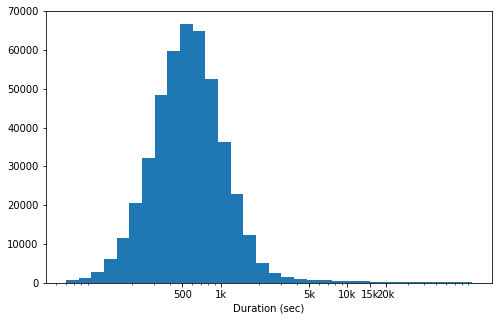

```python
# there's a long tail in the distribution, so let's put it on a log scale instead
log_binsize = 0.1
bins = 10 ** np.arange(1.78, np.log10(bike['duration_sec'].max())+log_binsize, log_binsize)

plt.figure(figsize=[8, 5])
plt.hist(data = bike, x = 'duration_sec', bins = bins)
plt.xscale('log')
plt.xticks([500, 1e3, 5e3, 1e4, 1.5e4, 2e4], [500, '1k', '5k', '10k', '15k', '20k'])
plt.xlabel('Duration (sec)')
plt.show()
```

## Distribution of Start hour

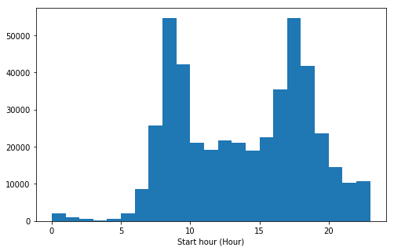

```python
# start with a standard-scaled plot
binsize = 1
bins = np.arange(0, bike['start_hour'].max()+binsize, binsize)

plt.figure(figsize=[8, 5])
plt.hist(data = bike, x = 'start_hour', bins = bins)
plt.xlabel('Start hour (Hour)')
plt.show()
```

## Distribution of Birth Year

Graph is left skewed with Millenials (1980 and younger) making mostly trips of larger duration however, there is a little concentration of people born after 1945-1950 using bike rentals as a convenient option as well maybe to keem themselves fit however quite significantly less compared to Millenials. Post 1995 born users are also not very bike savvy where you see a sudden dip after observing a peek for 1980-1995 born users

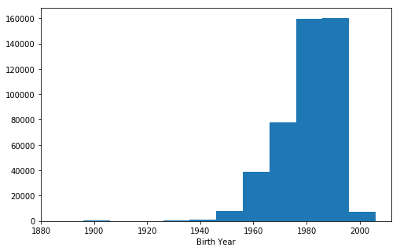

```python
# start with a standard-scaled plot
binsize = 10
bins = np.arange(1886, bike['member_birth_year'].max()+binsize, binsize)

plt.figure(figsize=[8, 5])
plt.hist(data = bike, x = 'member_birth_year', bins = bins)
plt.xlabel('Birth Year')
plt.show()
```

## Distribution of categorical variables

- Next up, the predictor variables of interest: day_of_week, month, member_gender and user_type are all categorical variables (nominal types). Due to that reason, we will plot countplot after ordering them by value_counts
- The max number of distinct trips were made during Tuesday whereas the least trips were made on Sunday which indicates that many people use the bike during the their working days - mostly during Tuesday, followed closely by WednesdaY
- The max number of distinct trips were made during October month and least during June month which shows summer time is not the most popular maybe because SF is still pleasant for bike riding during OCtober, whereas it gets really hot during June
- Subscribers make more number of trips (significantly larger) than the Customers (who casually reserve bikes)
- Male users are significantly more than the female users

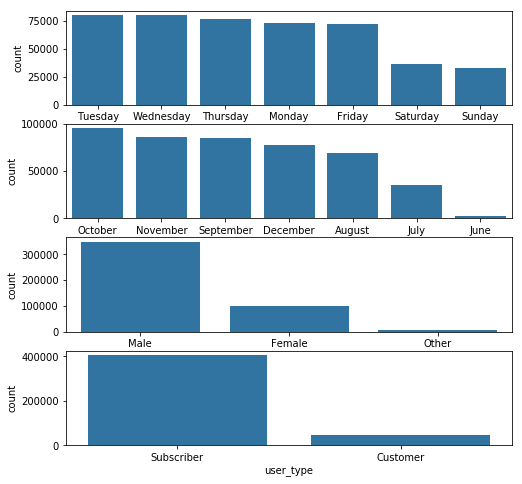

```python
# let's plot all 4 categorical variables together to get an idea of each nominal variable's distribution.

fig, ax = plt.subplots(nrows=4, figsize = [8,8])

day_order = bike['day_of_week'].value_counts().index
month_order = bike['month'].value_counts().index
gender_order = bike['member_gender'].value_counts().index
user_type_order = bike['user_type'].value_counts().index

default_color = sb.color_palette()[0]
sb.countplot(data = bike, x = 'day_of_week', color = default_color, order = day_order, ax = ax[0])
sb.countplot(data = bike, x = 'month', color = default_color, order = month_order, ax = ax[1])
sb.countplot(data = bike, x = 'member_gender', color = default_color, order = gender_order, ax = ax[2])
sb.countplot(data = bike, x = 'user_type', color = default_color, order = user_type_order, ax = ax[3])


plt.show()
```

## Duration vs Start Hour, Duration vs Birth Year

### Let's move on to looking at how duration, birth year and start hour correlate with one another (Quantitative (numeric) vs Quantitative (numeric) variables)

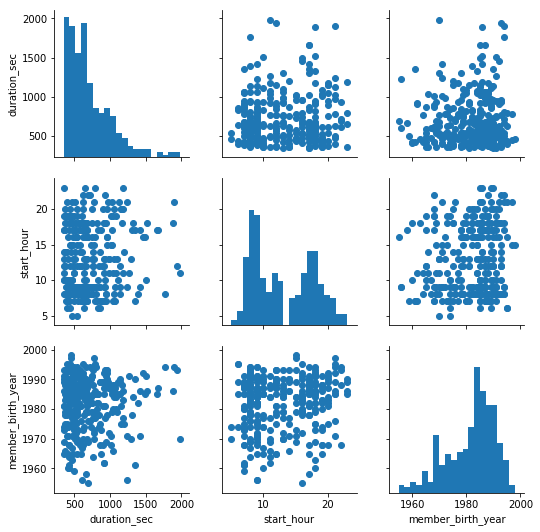

```python
# plot matrix: sample 500 diamonds so that plots are clearer and
# they render faster
samples = np.random.choice(bike.shape[0], 500, replace = False)
bike_samp = bike.loc[samples,:]

g = sb.PairGrid(data = bike_samp, vars = numeric_vars)
g = g.map_diag(plt.hist, bins = 20);
g.map_offdiag(plt.scatter)
```

## Duration vs Day of Week, Duration vs Month, Duration vs User type

- Since the categorical variables are nominal data types, there is no value determining if there is a positive OR negative correlation between categorical variables and numerical variables as far as there is a correlation

`What matters most is:`

- What day of week has the highest bike trip duration . From the results, it shows the median trip duration is maximum during SAturday, attributing to weekend time AND not necessarily to working hours of weekdays
- What month has the highest bike trip duration. From the results, it shows that the median trip duration is maximum during September, however there is not much difference across months which indicates a week co-relation
- Does the user being a subscriber OR Customer affect trip duration? Maybe, because Customers travel for larger duration based on the median value as determined from above box plot

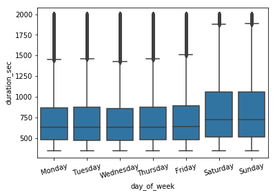

```python
day_of_week_segments = ['Monday','Tuesday','Wednesday','Thursday','Friday','Saturday','Sunday']
dayOfWeekclasses = pd.api.types.CategoricalDtype(ordered = False, categories = day_of_week_segments)
bike['day_of_week'] = bike['day_of_week'].astype(dayOfWeekclasses);

base_color = sb.color_palette()[0]
sb.boxplot(data = bike, x = 'day_of_week', y  = 'duration_sec', color = base_color);
plt.xticks(rotation = 15);
```

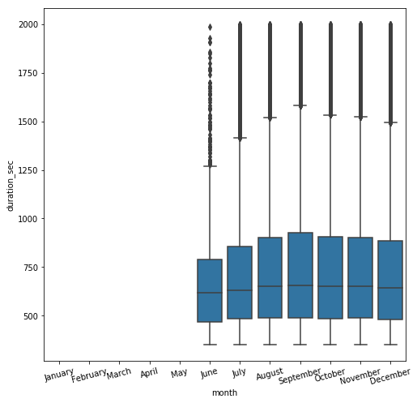

```python
plt.figure(figsize = [8, 8])

month_segments = ['January','February','March', 'April','May', 'June', 'July', 'August', 'September', 'October', 'November', 'December']
monthclasses = pd.api.types.CategoricalDtype(ordered = False, categories = month_segments)
bike['month'] = bike['month'].astype(monthclasses);

base_color = sb.color_palette()[0]
sb.boxplot(data = bike, x = 'month', y  = 'duration_sec', color = base_color);
plt.xticks(rotation = 15);
```

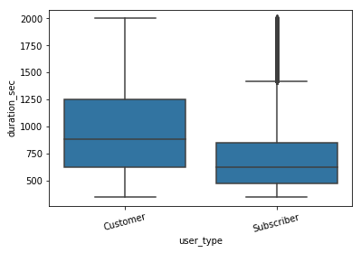

```python
user_type_segments = ['Customer','Subscriber']
userTypeclasses = pd.api.types.CategoricalDtype(ordered = True, categories = user_type_segments)
bike['user_type'] = bike['user_type'].astype(userTypeclasses);

base_color = sb.color_palette()[0]
sb.boxplot(data = bike, x = 'user_type', y  = 'duration_sec', color = base_color);
plt.xticks(rotation = 15);
```

## Duration and Birth Year by Day of week

It was observed that for different days of week, users of different age groups used the bike differently

- On Monday and Tuesday, users born between 1960 and 1970 used the bike for longer duration (maybe owing to Fitness reasons). - However there is a large number of Millenials who are using bikes too overall during weekdays. The number grows on Wednesday, Thursday and Friday and they outmatch the older aged people (More # of millenials + higher trip duration)
- On Saturday and Sunday, the bike was used more by the Millenials for a longer time, however there were users born between 1965-1970 who also matched the trend of millenials
- Overall, the mellenials seem to be using the bike more often and for a larger duration (As was observed in the Multivariate trend too)

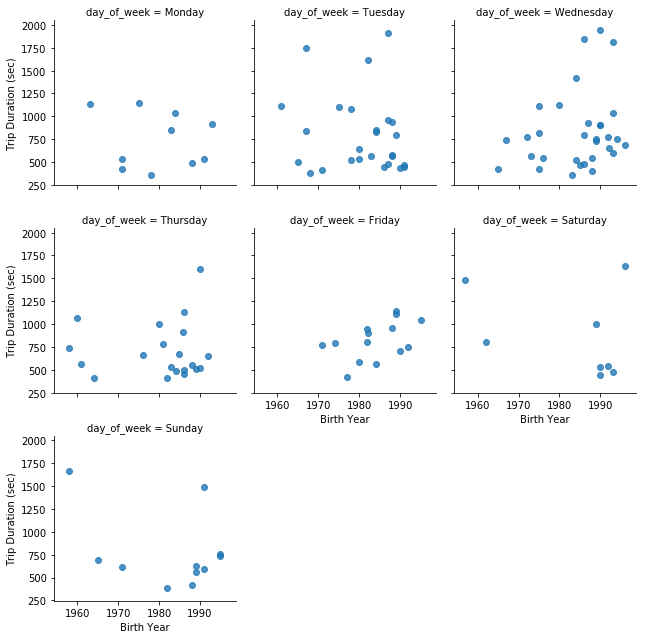

```python
# Use a sample to prevent overplotting
np.random.seed(2018)
sample = np.random.choice(bike.shape[0], 200, replace = False)
bike_subset = bike.loc[sample]

g = sb.FacetGrid(data = bike_subset, col = 'day_of_week', col_wrap = 3, height = 3)
g = g.map (sb.regplot, 'member_birth_year', 'duration_sec', x_jitter = 0.03, fit_reg = False);
g.add_legend()
g.set_xlabels('Birth Year')
g.set_ylabels('Trip Duration (sec)')
```

## Duration and Birth Year by User type

As a part of bivariate plotting, it was observed that the customers spent larger average duration of trip than Subscriber. As a part of this multivariate plotting, it can be observed that the Subscriber base being more (as was also observed in Univariate plotting) has more dense chart, but w.r.t the trend of user base vs Birth year and Trip duration, it can be concluded that:

ii) Subscribers aged 1985-1995 are most bike savvy (i.e. Millenial group) , however there is not a consistent trend in terms of how long they spend time on the bike (it has varied colors and each millenial biker spends different time on bike trips).

iv) Subscribers belonging to age group that is relatively younger but non as young as Millenial generation (1965-1975) spend lesser time on biking - mostly less than 800 seconds across this subset of user base and also the count of such users is lower than Millenials but little higher than Older generation (Since the color is darker)

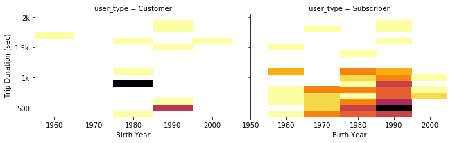

```python
# Use a sample to prevent overplotting
np.random.seed(2018)
sample = np.random.choice(bike.shape[0], 200, replace = False)
bike_subset = bike.loc[sample]

g = sb.FacetGrid(data = bike_subset, col = 'user_type', col_order =['Customer','Subscriber'],
                 col_wrap = 3, height = 3, aspect = 1.5)
g = g.map(hist2dgrid, 'member_birth_year', 'duration_sec', color = 'inferno_r')
g.set_xlabels('Birth Year')
g.set_ylabels('Trip Duration (sec)')

plt.show()
```

## Duration and Birth year by UserType and Month

As can be seen, September looks more spread out in terms of bike usage across all age groups.

However, OCtober month has compared to other months,

i) a few users with larger trip duration though a few number

ii) a wider concentraion of users aged 1975-1995 using bikes more consistently though for a smaller duration of trip making this month more popular for users belonging a narrower range of users as compared to September, which has a spread across all age groups, however with lesser concentration (# of trips) and lesser duration (duration time)

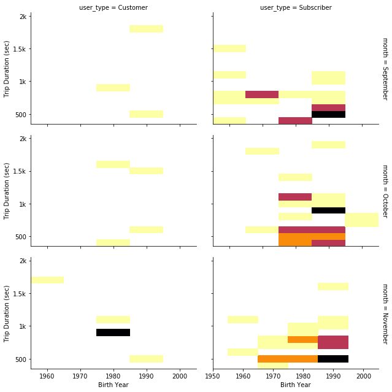

```python
# create faceted heat maps on levels of month and day of week

np.random.seed(2018)
sample = np.random.choice(bike.shape[0], 200, replace = False)
bike_subset = bike.loc[sample]

g = sb.FacetGrid(data = bike_subset, row = 'month', row_order = ['September','October','November'],
                 col = 'user_type', height = 3, aspect = 1.5, margin_titles = True)
g = g.map(hist2dgrid, 'member_birth_year', 'duration_sec', color = 'inferno_r')
g.set_xlabels('Birth Year')
g.set_ylabels('Trip Duration (sec)')

plt.show()
```

## Duration by User Type and Day of Week

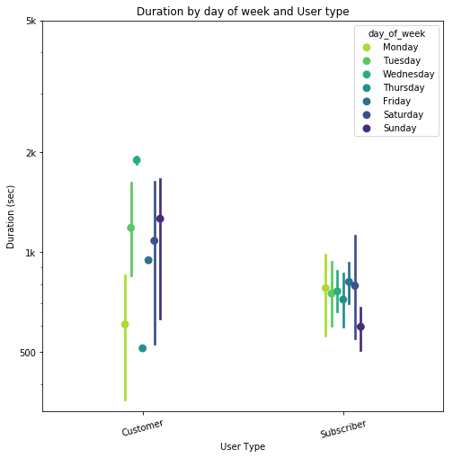

```python
 # Color encoding w/ FAceted chart : Duration, birth year w/ categorical variable: day of week

np.random.seed(2018)
sample = np.random.choice(bike.shape[0], 200, replace = False)
bike_subset = bike.loc[sample]

plt.figure(figsize = [8, 8])
ax = sb.pointplot(data = bike_subset, x = 'user_type', y= 'duration_sec', hue = 'day_of_week', dodge = True, linestyles = "", palette = 'viridis_r')

plt.yscale('log')
plt.yticks([500, 1e3, 2e3, 5e3], ['500', '1k', '2k', '5k'])
ax.set_yticklabels([], minor = True)
plt.xticks(rotation = 15);
plt.ylabel('Duration (sec)');
plt.xlabel('User Type');
plt.title('Duration by day of week and User type')
plt.show();
```

## Duration by User Type and Month

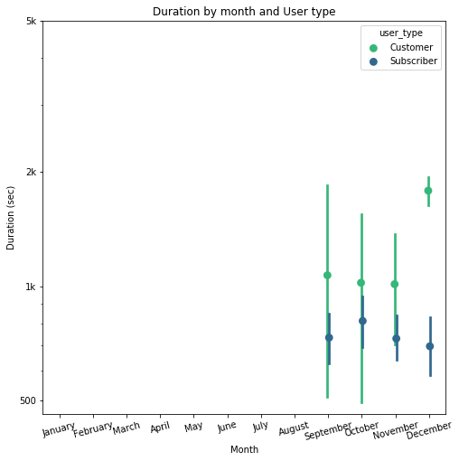

```python
 # Color encoding w/ FAceted chart : Duration, birth year w/ categorical variable: day of week

plt.figure(figsize = [8, 8])
ax = sb.pointplot(data = bike_subset, x = 'month', y= 'duration_sec', hue = 'user_type', dodge = True, linestyles = "", palette = 'viridis_r')

plt.yscale('log')
plt.yticks([500, 1e3, 2e3, 5e3], ['500', '1k', '2k', '5k'])
ax.set_yticklabels([], minor = True)
plt.xticks(rotation = 15);
plt.ylabel('Duration (sec)');
plt.xlabel('Month');
plt.title('Duration by month and User type')
plt.show();
```